# Correlational Analysis in R

Clay Ford

2025-02-03

## Email from Jemima

I was wondering if you knew of a way to analyze correlational data with treatments in R? I’ve written the code for without treatments but I’m unsure of how to make R analyze it via different treatments. The treatments (3) are in the column “Salt”

## Read in data

```r
library(readxl)
library(ggplot2)
library(psych)

licor <- read_excel("Licor Data for R.xlsx")
```

Subset data for variables of interest and include treatment variable

```r
d <- licor[,c("A","Ca","Ci","gsw","Salt")]
summary(d) # check for missings
```

```
##        A                Ca              Ci             gsw
##  Min.   :-5.105   Min.   :419.0   Min.   :178.5   Min.   :0.02251
##  1st Qu.: 1.416   1st Qu.:420.0   1st Qu.:288.4   1st Qu.:0.08258
##  Median : 5.487   Median :420.0   Median :331.2   Median :0.11984
##  Mean   : 6.224   Mean   :420.0   Mean   :337.6   Mean   :0.13571
##  3rd Qu.:10.461   3rd Qu.:420.0   3rd Qu.:386.0   3rd Qu.:0.15878
##  Max.   :30.418   Max.   :421.5   Max.   :531.9   Max.   :0.69817
##      Salt
##  Length:593
##  Class :character
##  Mode  :character
##
##
##
```

```r
table(d$Salt) # sample sizes within treatment groups
```

```
##
## control    high     low
##     191     200     202
```

## Visualize with scatterplots and trend lines

Get all combinations of two variables

```r
var_pairs <- combn(x = c("A","Ca","Ci","gsw"), m = 2)
var_pairs
```

```
##      [,1] [,2] [,3]  [,4] [,5]  [,6]
## [1,] "A"  "A"  "A"   "Ca" "Ca"  "Ci"
## [2,] "Ca" "Ci" "gsw" "Ci" "gsw" "gsw"
```

Write a function to help us make the plots for all three levels of Salt.

```r
f <- function(df, x, y){
  ggplot(df) +
    aes(x = .data[[x]], y = .data[[y]]) +
    geom_point() +
    geom_smooth() +
    facet_wrap(~Salt) +
    ggtitle(paste(y, "vs", x))
}
```

Apply the function to the variable pairs.

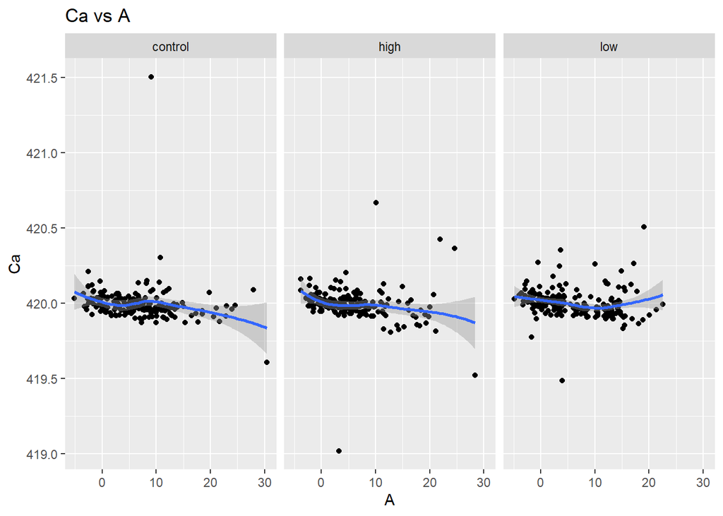

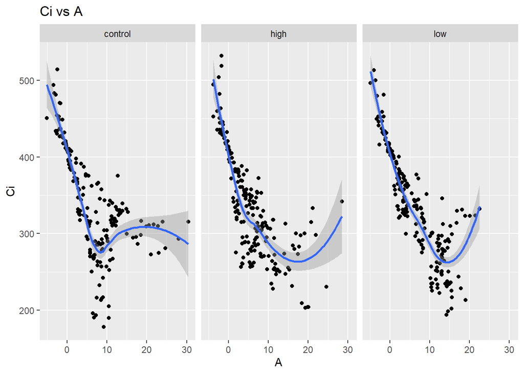

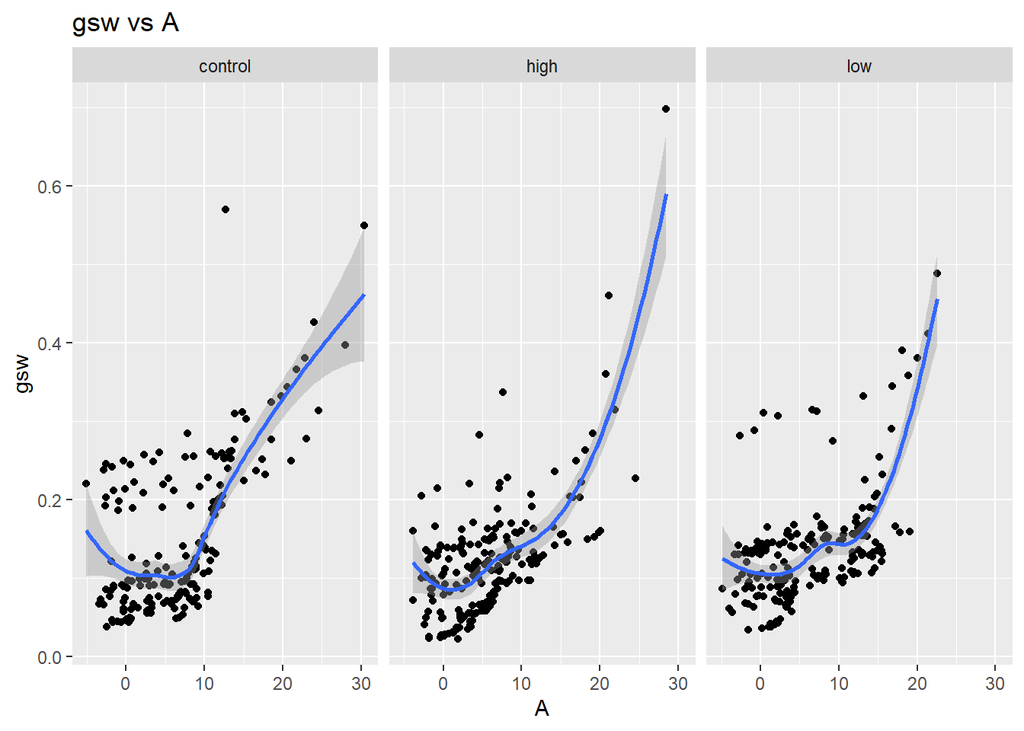

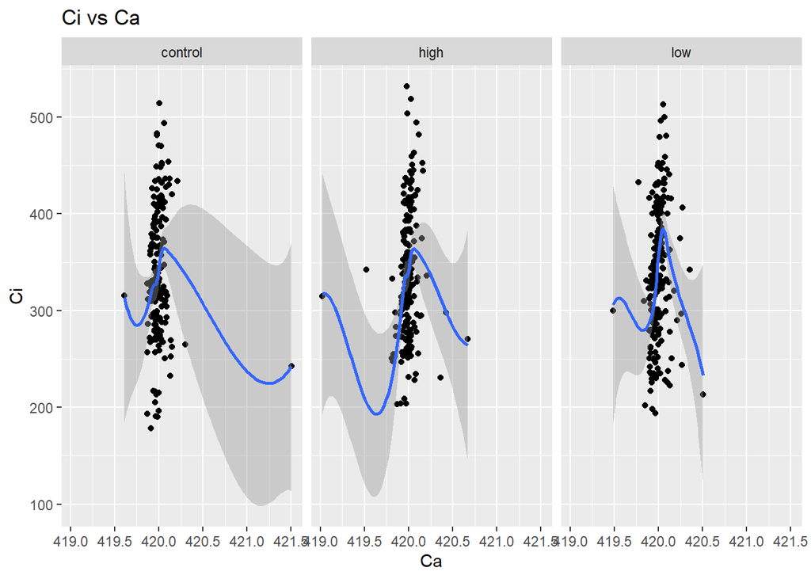

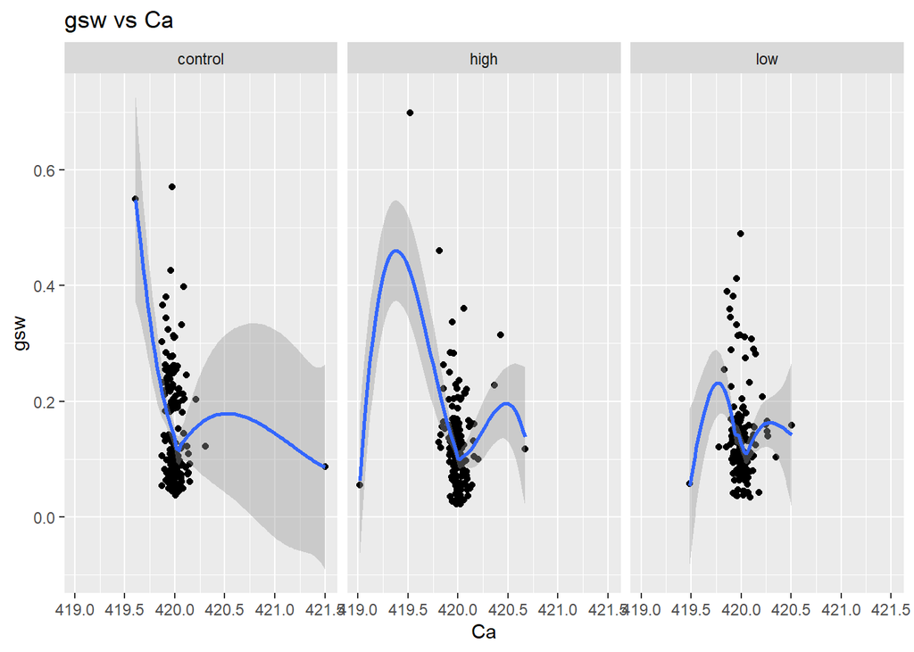

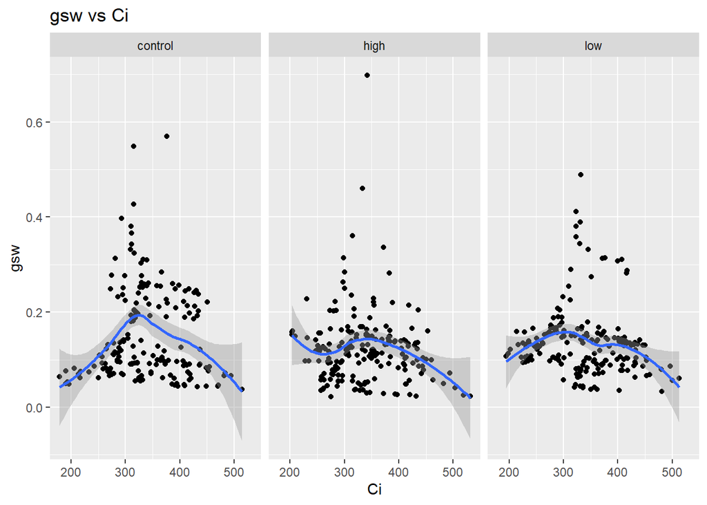

```r
apply(var_pairs, 2, function(x)f(df = d, x = x[1], y = x[2]))
```

It looks like Ci vs A and gsw vs A are the only two pairs that exhibit any correlation, though it’s not clear there are any differences between the three levels of Salt.

## Single correlation test

The code in this section and the next come from the help page for the `r.test()` function in the {psych} package.

Perform a single correlation test for gsw vs A where Salt = control and Salt = high. When calculating correlations, I set `method = "spearman"` since the plots showed some non-linearity.

```r
# correlation between A and gsw given Salt == "control"
r1 <- cor.test(~ A + gsw, data = d, subset = Salt == "control",
               method = "spearman")

# correlation between A and gsw given Salt == "high"
r2 <- cor.test(~ A + gsw, data = d, subset = Salt == "high",
         method = "spearman")

# view the correlations
cbind("Salt = control" = r1$estimate, "Salt = high" = r2$estimate)
```

```
##     Salt = control Salt = high
## rho      0.5547844   0.5133893
```

Now run test to see if the difference in correlations is plausible using the `r.test()` function.

```r
r.test(n = sum(d$Salt == "control"), r12 = r1$estimate, r34 = r2$estimate,
       n2 = sum(d$Salt == "high"))
```

```
## Correlation tests
## Call:r.test(n = sum(d$Salt == "control"), r12 = r1$estimate, r34 = r2$estimate,
##     n2 = sum(d$Salt == "high"))
## Test of difference between two independent correlations
##  z value 0.57    with probability  0.57
```

The probability of seeing a difference this big (or bigger) between the correlations, assuming there is no real difference between the two, is pretty high (p = 0.57). We fail to conclude there is any important difference between the two correlations.

## Compare two correlation matrices

Compare all pairs of variables where Salt = control and Salt = high. This is probably a little more efficient than doing two at a time.

First we create the two correlation matrices and view the correlations. To do this I use the `lowerUpper()` function from the {psych} package. The R1 correlations are displayed below the diagonal, while the R2 correlations are displayed above the diagonal.

```r
# correlation matrix given Salt == "control"
R1 <- cor(d[d$Salt == "control", -5])

# correlation matrix given Salt == "high"
R2 <- cor(d[d$Salt == "high", -5])

# show the two correlations
round(lowerUpper(lower = R1, upper = R2), 2)
```

```
##         A    Ca    Ci   gsw
## A      NA -0.16 -0.74  0.62
## Ca  -0.16    NA  0.11 -0.17
## Ci  -0.63  0.00    NA -0.08
## gsw  0.64 -0.20  0.03    NA
```

For example, we see the correlation between Ci vs A is -0.63 when salt = control (lower corner) and -0.74 when salt = high (upper corner)

Now run the test to compare all correlations at once.

```r
# compare the correlation matrices
test <- r.test(n=sum(d$Salt == "control"), r12 = R1, r34 = R2,
       n2 = sum(d$Salt == "high"))

# view the p-values, rounded to 3 decimal places
round(test$p, 3)
```

```
##         A    Ca    Ci   gsw
## A     NaN 0.974 0.030 0.722
## Ca  0.974   NaN 0.274 0.784
## Ci  0.030 0.274   NaN 0.278
## gsw 0.722 0.784 0.278   NaN
```

The difference in correlations between Ci vs A may be of interest (p = 0.03). However, given that we ran six different hypothesis tests we may want to adjust the p-values to protect against false positives.

Below we extract the six p-values and use `p.adjust()` to adjust the p-values using the default Holm method. We then insert the adjusted p-values into the upper corner of the p-value matrix, but leave the original p-values in the lower corner.

```r
# show the p values of the difference between the two matrices
adjusted <- p.adjust(test$p[upper.tri(test$p)])
both <- test$p
both[upper.tri(both)] <- adjusted

# The lower off diagonal are the raw p-values,
# the upper off diagonal are the adjusted p-values
round(both,digits=2)
```

```
##        A   Ca   Ci gsw
## A    NaN 1.00 0.18   1
## Ca  0.97  NaN 1.00   1
## Ci  0.03 0.27  NaN   1
## gsw 0.72 0.78 0.28 NaN
```

After adjustment, the p-value comparing the correlations for Ci vs A is now 0.18. The code above can be re-run to compare Salt = “control” to Salt = “low”, or Salt = “low” to Salt = “high”. Judging from the plots, it seems unlikely any important differences between correlations will be detected.

## References

- R Core Team (2024). *R: A Language and Environment for Statistical Computing*. R Foundation for Statistical Computing, Vienna, Austria. https://www.R-project.org/.
- Revelle, W. (2024). *psych: Procedures for Psychological, Psychometric, and Personality Research*. Northwestern University, Evanston, Illinois. R package version 2.4.12, https://CRAN.R-project.org/package=psych.
- Wickham, H. (2016 ) *ggplot2: Elegant Graphics for Data Analysis*. Springer-Verlag New York.